# Getting started with LaTeX-style math

## What is this about?

LaTeX is a professional typesetting system used throughout mathematics and the sciences. Its name comes from TeX, whose final letter represents the Greek letter chi, so it is usually pronounced “lah-tech” or “lay-tech.”

A complete LaTeX document can control fonts, margins, references, page layout, and many other details. You do not need that machinery for Advanced Astronomy notebooks. Jupyter Markdown cells use MathJax to render a substantial subset of LaTeX mathematical syntax, while this web guide uses KaTeX. We will simply call the shared math notation “LaTeX-style math.”

## Enter math in Markdown

Use single dollar signs for short mathematics within a sentence. For example, the source `$P = 2\pi\sqrt{a^3/(GM)}$` renders as $P = 2\pi\sqrt{a^3/(GM)}$.

Use double dollar signs for a displayed equation. Put the delimiters and the equation at the top level, separated from the surrounding prose by blank lines:

```markdown
$$
P = 2\pi\sqrt{\frac{a^3}{GM}}
$$
```

That source renders as

$$P = 2\pi\sqrt{\frac{a^3}{GM}}.$$

## Symbols

Many commands are easy to recognize: write a backslash followed by the command name.

| Name | Rendered | Source inside math delimiters |
| --- | --- | --- |
| multiplication | $\times$ | `\times` |
| infinity | $\infty$ | `\infty` |
| limit | $\lim$ | `\lim` |
| summation | $\sum$ | `\sum` |
| integral | $\int$ | `\int` |
| right arrow | $\to$ | `\to` |
| approximately equal | $\approx$ | `\approx` |

Greek letters work similarly: `\alpha` gives $\alpha$, `\beta` gives $\beta$, and `\Gamma` gives $\Gamma$. Several uppercase Greek letters look identical to Latin letters, so write ordinary `A` rather than looking for a command such as `\Alpha`.

## Superscripts, subscripts, fractions, and grouping

- Use `^` for a superscript and `_` for a subscript.
- Use braces to group more than one character: `r^2` but `r^{12}`.
- Write a fraction as `\frac{numerator}{denominator}`.
- Use `\left` and `\right` when delimiters should grow with their contents.

For example, the source `$v_{\mathrm{esc}} = \sqrt{2GM/R}$` renders as $v_{\mathrm{esc}} = \sqrt{2GM/R}$.

## Multiline equations

Within Markdown math, an `aligned` block gives you controlled line breaks and alignment. Put `&` before the alignment point and use `\\` for a new line:

```markdown
$$
\begin{aligned}
\int_a^b u v'\,dx
  &= \int_a^b (uv)'\,dx - \int_a^b u'v\,dx \\
  &= \left.uv\right|_a^b - \int_a^b u'v\,dx
\end{aligned}
$$
```

This renders as

$$\begin{aligned}
\int_a^b u v'\,dx
&= \int_a^b (uv)'\,dx - \int_a^b u'v\,dx \\
&= \left.uv\right|_a^b - \int_a^b u'v\,dx.
\end{aligned}$$

The `\left.` in the second line creates an invisible left delimiter so that the evaluation bar on the right can size correctly.

## Common mistakes

- Dollar signs delimit math; they are not part of the LaTeX command itself.
- Commands begin with a backslash: `\theta`, not `/theta`.
- Group multi-character superscripts and subscripts with braces.
- Pair `\left` with `\right`. Use a period for an invisible partner, as in `\left.`.
- Keep display equations outside lists, tables, block quotes, links, and code blocks.

## A compact reference

Jim Hefferon’s *LaTeX Math for Undergrads* is a useful two-page symbol and syntax reference.

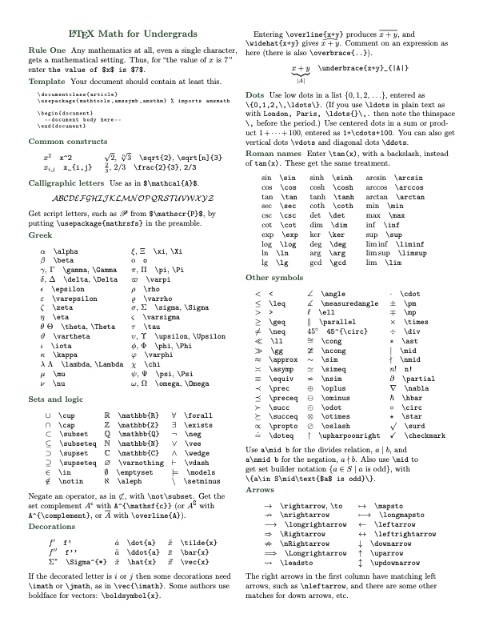

First page of Jim Hefferon’s LaTeX mathematics cheat sheet.

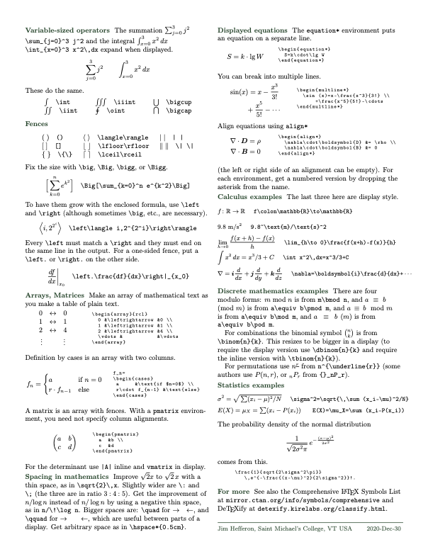

Second page of Jim Hefferon’s LaTeX mathematics cheat sheet.

Download the local PDF or visit the [author’s source page](https://jheffero.w3.uvm.edu/undergradmath/). The reference is shared under the Creative Commons Attribution-ShareAlike 4.0 International license.